# hw-COVID19-leonahoxha

Author

Leona Hoxha

# 1 Covid-19

The development of the COVID-19 pandemic 2019-2022.

## 1.1 Loading Packages and the Data

```r
suppressWarnings({
library(tidyverse)
library(purrr)
library(patchwork)
library(dplyr)
library(ggplot2)
library(corrplot)
library(correlation)
library(dplyr)
library(knitr)
library(stats)
library(tidyr)})
```

Two data sets are provided in the repository:

1. Daily numbers of new cases of COVID-19 and new COVID-19 related deaths in most countries in the world as collected by the World Health Organization (WHO) on a daily basis. The data is from 2022-09-30.
2. World Bank Development Indicators (WDI) with some socio-economic indicators as provided for most countries in the world.

```r
wdi <- read.csv("data/WDI.csv")
who <- read.csv("data/WHO-COVID-19.csv")

who$Date_reported <- as.Date(who$Date_reported)
```

# 2 COVID-19 time evolution

## 2.1 Covid Cases and Deaths in Germany’s 1st wave

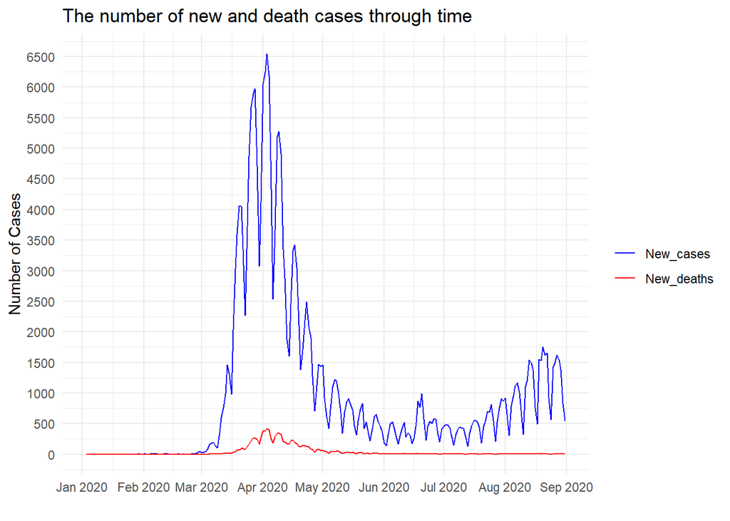

```r
who|>
      filter(Country=="Germany", Date_reported<="2020-08-31")|>
    pivot_longer(cols = c("New_cases", "New_deaths"), names_to = "Case_Death", values_to = "Count")|>
    ggplot(aes(x = Date_reported, y = Count, color = Case_Death)) +
  geom_line(aes(group=Case_Death))+
      labs(x = "",
       y = "Number of Cases",
       title = "The number of new and death cases through time",
       color="")+
      scale_color_manual(values = c("New_cases" = "blue", "New_deaths" = "red"))+
      theme_minimal()+
  scale_y_continuous(breaks = seq(0, max(who$New_cases), by = 500))+
  scale_x_date(date_labels = "%b %Y", date_breaks = "1 month")
```

## 2.2 Cumulative cases in Germany, Italy, France, and UK

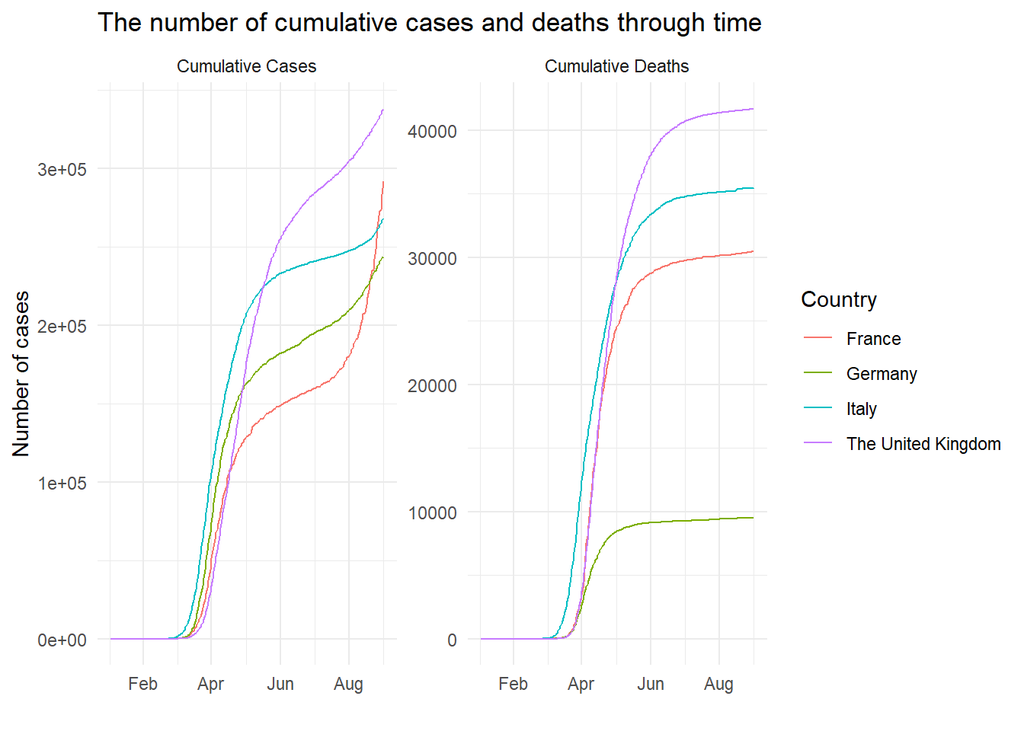

```r
who|>
  filter(Country %in% c("Germany", "Italy", "France", "The United Kingdom"), Date_reported<="2020-08-31")|>
  group_by(Country)|>
  arrange(Country, Date_reported)|>
  mutate(C_cases=cumsum(New_cases), C_deaths=cumsum(New_deaths))|>
  select(Country, Date_reported, C_cases, C_deaths)|>
  pivot_longer(cols = c("C_cases", "C_deaths"), names_to = "Cases_deaths", values_to = "Count")|>
  ggplot(aes(x=Date_reported, y=Count, color=Country))+
  geom_line(aes(group=Country))+
  labs(x = "",
       y = "Number of cases",
       title = "The number of cumulative cases and deaths through time")+
  facet_wrap(~ Cases_deaths,scales = "free_y",labeller = labeller(Cases_deaths = c("C_cases" = "Cumulative Cases", "C_deaths" = "Cumulative Deaths")))+
  scale_x_date(date_labels = "%b", date_breaks = "2 month")+
  theme_minimal()
```

From looking at these two panels, we can see that all four countries experienced the COVID-19 wave starting around March-April 2020, but each country managed it differently. In June, the UK had the highest number of new cases, while France had the fewest. Surprisingly, in September, France had more cases than both Germany and Italy.

Switching to the death cases wave, it began in April 2020 for all four countries. The second panel reveals how each country treated COVID-19 patients. The data indicates that the UK struggled and had the highest number of deaths among the four countries. In contrast, Germany had the fewest deaths, quite lower than the other countries, suggesting effective handling of the situation.

## 2.3 Smoothing daily data

```r
smooth3 <- function(x) {
  (x + lag(x, n = 1, default = 0) + lag(x, n = 2, default = 0)) / 3
}

smooth7 <- function(x) {
  (x + lag(x, n = 1, default = 0) + lag(x, n = 2, default = 0) + lag(x, n = 3, default = 0) +
     lag(x, n = 4, default = 0) + lag(x, n = 5, default = 0) + lag(x, n = 6, default = 0)) / 7
}

smooth10 <- function(x) {
  (x + lag(x, n = 1, default = 0) + lag(x, n = 2, default = 0) + lag(x, n = 3, default = 0) +
     lag(x, n = 4, default = 0) + lag(x, n = 5, default = 0) + lag(x, n = 6, default = 0) +
     lag(x, n = 7, default = 0) + lag(x, n = 8, default = 0) + lag(x, n = 9, default = 0)) / 10
}

who_smoothed <- who|>
  group_by(Country)|>
  mutate(
    New_cases_smooth3 = smooth3(New_cases),
    New_cases_smooth7 = smooth7(New_cases),
    New_cases_smooth10 = smooth10(New_cases),
    New_deaths_smooth3 = smooth3(New_deaths),
    New_deaths_smooth7 = smooth7(New_deaths),
    New_deaths_smooth10 = smooth10(New_deaths)
  )
```

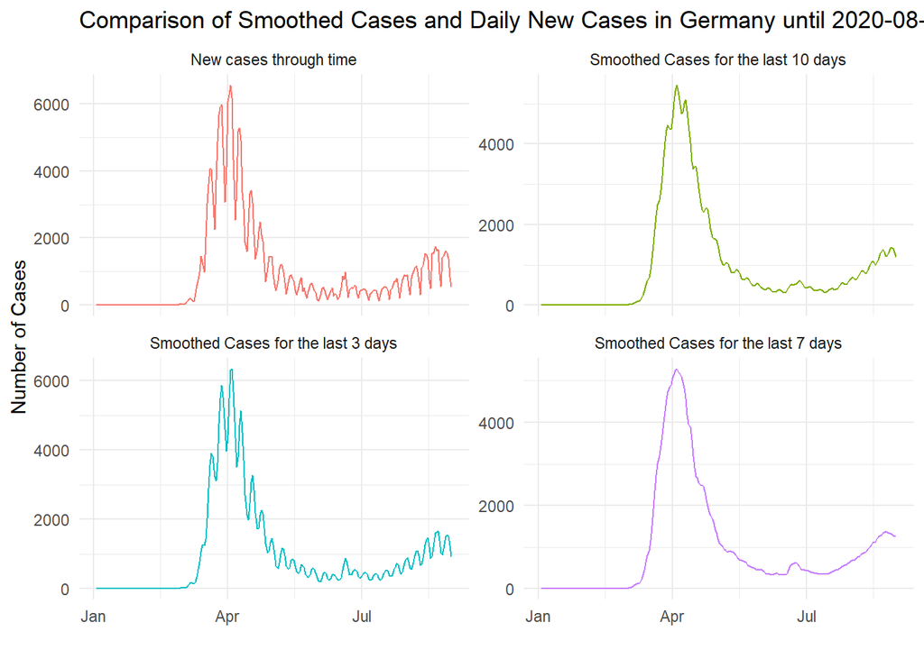

```r
who_smoothed|>
  filter(Country == "Germany", Date_reported <= "2020-08-31") |>
  pivot_longer(
    cols = c("New_cases", "New_cases_smooth3", "New_cases_smooth7", "New_cases_smooth10"),
    names_to = "Smooth_Variable",
    values_to = "Count"
  )|>
  ggplot(aes(x = Date_reported, y = Count, color = Smooth_Variable)) +
  geom_line(aes(group = Smooth_Variable)) +
  labs(
    x = "",
    y = "Number of Cases",
    title = "Comparison of Smoothed Cases and Daily New Cases in Germany until 2020-08-31",
    color = ""
  ) +
  theme_minimal() +
  facet_wrap(~ Smooth_Variable, scales = "free_y", labeller = labeller(Smooth_Variable = c("New_cases" = "New cases through time","New_cases_smooth3" = "Smoothed Cases for the last 3 days", "New_cases_smooth7" = "Smoothed Cases for the last 7 days", "New_cases_smooth10" = "Smoothed Cases for the last 10 days"))) +
  theme(legend.position = "none")
```

Here we can see the New cases(Daily data) graph, and the other three smoothed graphs for the last 3 days, 7 days and 10 days. We notice that using a 7-day window makes the data smoother. This means that using a 7-day window provides a balance between capturing the trends and reducing daily variations. The reason it’s better than a 10-day window might be because the data relies more on weekly patterns. If we use the last 10 days, there could be more ups and downs between each of those 10 days. It all depends on how the data is reported.

## 2.4 How do deaths follow cases?

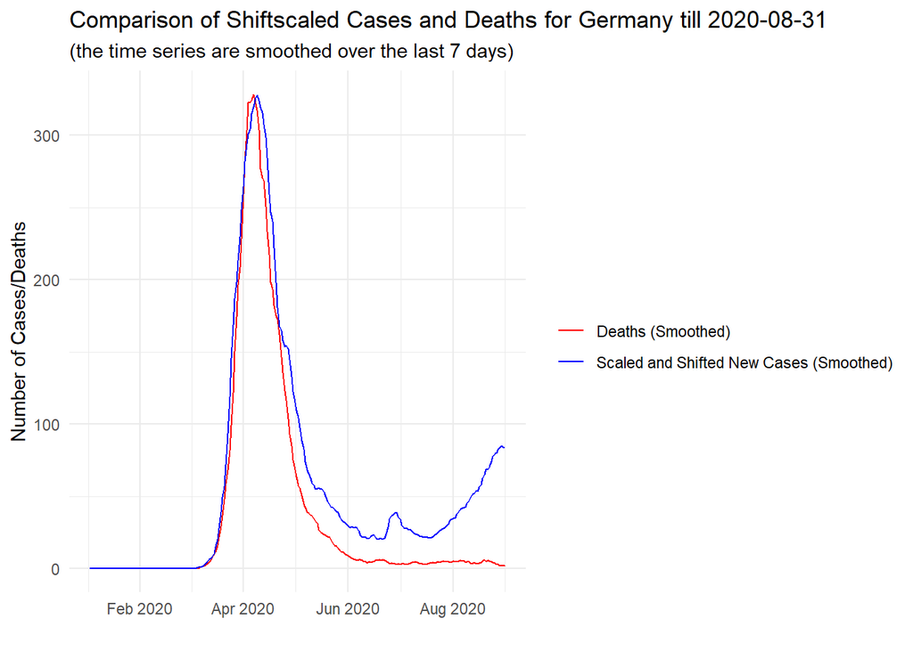

```r
shiftscale <- function(x, shift, scale) {
  lagged_x <- lag(x, shift, default = 0)
  scaled_x <- lagged_x * scale
  return(scaled_x)}

who_smoothed|>
  mutate(shiftscale_cases = shiftscale(New_cases_smooth7, 5, 0.062))|>
  filter(Country == "Germany", Date_reported <= "2020-08-31")|>
  pivot_longer(cols = c("shiftscale_cases", "New_deaths_smooth7"),
               names_to = "Variable",
               values_to = "Count")|>
  ggplot(aes(x = Date_reported, y = Count, color = Variable)) +
  geom_line(aes(group = Variable)) +
  labs(x = "",
       y = "Number of Cases/Deaths",
       title = "Comparison of Shiftscaled Cases and Deaths for Germany till 2020-08-31",
       subtitle = "(the time series are smoothed over the last 7 days)",
       color = "")+
  scale_color_manual(values = c("New_deaths_smooth7" = "red","shiftscale_cases" = "blue"),
                     labels = c("Deaths (Smoothed)", "Scaled and Shifted New Cases (Smoothed)"))+
  scale_x_date(date_labels = "%b %Y", date_breaks = "2 month")+
  theme_minimal()
```

I made this graph using shift=5 and scale=0.062. The Scaled-Shifted New Cases and Deaths graphs overlap well. With a shift of 5, it looks like the Deaths wave comes five days after the New Cases wave. Also, from the scale of 0.062, we can say that about 6.2% of the New Cases are Death Cases.

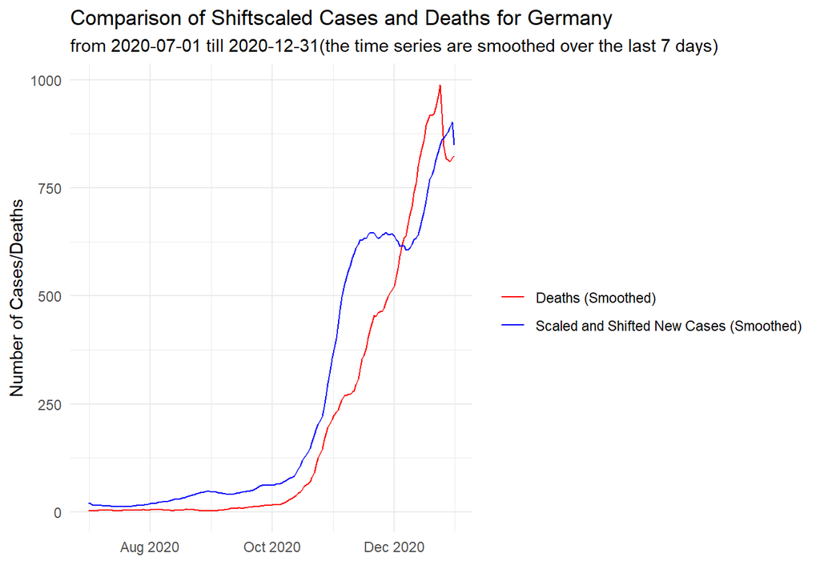

```r
who_smoothed|>
  mutate(shiftscale_cases = shiftscale(New_cases_smooth7, 6, 0.035))|>
  filter(Country == "Germany", Date_reported >= "2020-07-01", Date_reported <= "2020-12-31")|>
  pivot_longer(cols = c("shiftscale_cases", "New_deaths_smooth7"),
               names_to = "Variable",
               values_to = "Count")|>
  ggplot(aes(x = Date_reported, y = Count, color = Variable)) +
  geom_line(aes(group = Variable)) +
  labs(x = "",
       y = "Number of Cases/Deaths",
       title = "Comparison of Shiftscaled Cases and Deaths for Germany",
       subtitle = "from 2020-07-01 till 2020-12-31(the time series are smoothed over the last 7 days)",
       color = "")+
  scale_color_manual(values = c("New_deaths_smooth7" = "red","shiftscale_cases" = "blue"),
                     labels = c("Deaths (Smoothed)", "Scaled and Shifted New Cases (Smoothed)"))+
  scale_x_date(date_labels = "%b %Y", date_breaks = "2 month")+
  theme_minimal()
```

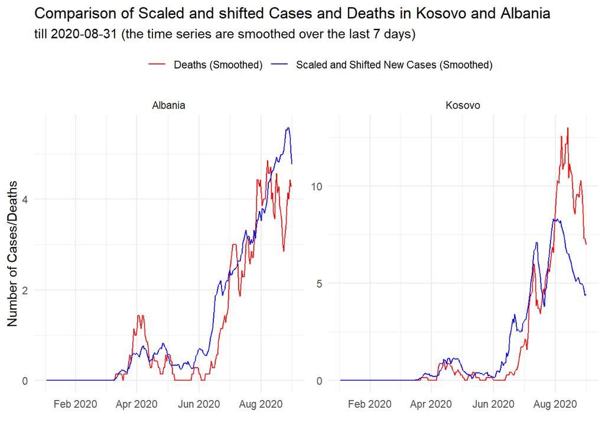

```r
country1 <- "Kosovo[1]"
country2 <- "Albania"

who_smoothed|>
  mutate(shiftscale_cases_second = shiftscale(New_cases_smooth7, 0, 0.035))|>
  filter(Country %in% c(country1, country2), Date_reported <= "2020-08-31")|>
  pivot_longer(cols = c("shiftscale_cases_second", "New_deaths_smooth7"),
               names_to = "Variable",
               values_to = "Count")|>
  ggplot(aes(x = Date_reported, y = Count, color = Variable)) +
  geom_line(aes(group = Variable)) +
  labs(x = "",
       y = "Number of Cases/Deaths",
       title ="Comparison of Scaled and shifted Cases and Deaths in Kosovo and Albania",
       subtitle = "till 2020-08-31 (the time series are smoothed over the last 7 days)",
       color = "Variable")+
  theme_minimal()+
  scale_color_manual(
    values = c("New_deaths_smooth7" = "red","shiftscale_cases_second" = "blue"),
    labels = c("Deaths (Smoothed)", "Scaled and Shifted New Cases (Smoothed)")) +
  facet_wrap(~Country, scales = "free_y", labeller = labeller(Country = c("Kosovo[1]" = "Kosovo", "Albania" = "Albania"))) +
  scale_x_date(date_labels = "%b %Y", date_breaks = "2 month")+
  theme(legend.position = "top", legend.title = element_blank())
```

## 2.5 When does the wave break?

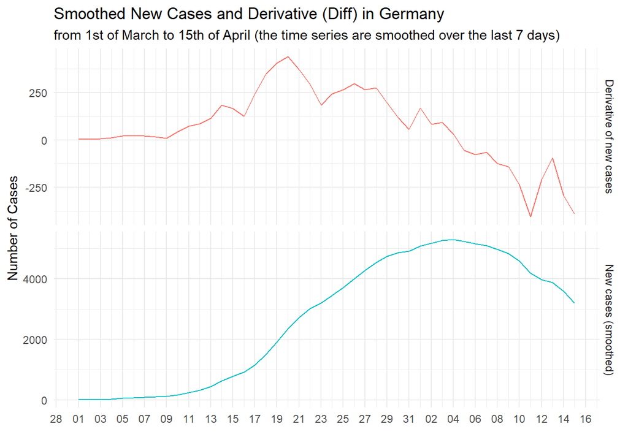

```r
# Convert Date_reported to Date class

who_smoothed |>
  mutate(Diff_cases_smooth7 = New_cases_smooth7 - lag(New_cases_smooth7, default = 0)) |>
  filter(Country == "Germany", Date_reported >= "2020-03-01", Date_reported <= "2020-04-15") |>
  pivot_longer(cols = c("New_cases_smooth7", "Diff_cases_smooth7"),
               names_to = "Variable",
               values_to = "Count") |>
  ggplot(aes(x = Date_reported, y = Count, color = Variable)) +
  geom_line(aes(group = Variable)) +
  labs(x = "",
       y = "Number of Cases",
       title = "Smoothed New Cases and Derivative (Diff) in Germany",
       subtitle = "from 1st of March to 15th of April (the time series are smoothed over the last 7 days)",
       color = "Variable") +
  theme_minimal() +
  facet_grid(Variable ~ ., scales = "free_y", labeller = labeller(Variable = c("Diff_cases_smooth7" = "Derivative of new cases", "New_cases_smooth7" = "New cases (smoothed)"))) +
  scale_x_date(date_breaks = "2 days", date_labels = "%d") +
  theme(legend.position = "none")
```

# 3 World Development Indicators in R

## 3.1 Changing the names of the variables

```r
wdi <- wdi|>
  rename(
    urban_pop = Urban.population....of.total.population.,
    rural_pop = Rural.population....of.total.population.,
    pop_lower_half_median = Proportion.of.people.living.below.50.percent.of.median.income....,
    pop = Population..total,
    pop_older65 = Population.ages.65.and.above....of.total.population.,
    pop_density = Population.density..people.per.sq..km.of.land.area.,
    physicians_per_1000 = Physicians..per.1.000.people.,
    life_expectancy = Life.expectancy.at.birth..total..years.,
    gdp_per_capita = GDP.per.capita..PPP..current.international...
  )
```

## 3.2 Correlation matrix of all numerical indicators in the WDI data set

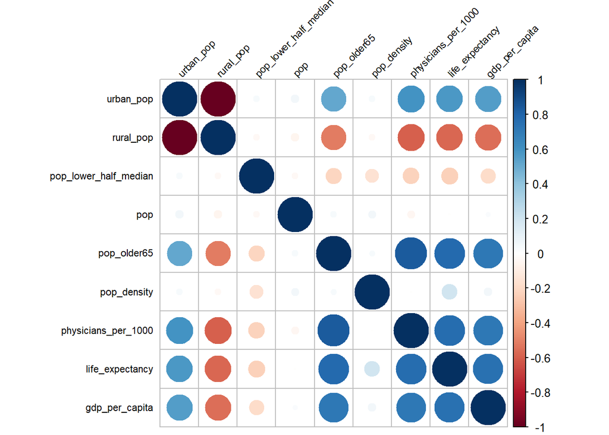

```r
cor_matrix <- cor(wdi[, sapply(wdi, is.numeric)], use = "complete.obs")

corrplot(cor_matrix, tl.cex = 0.7, tl.col = "black", tl.srt = 45)
```

# 4 Removing countries with NA’s and removing variables with NA’s

```r
wdi_noNA_small <- na.omit(wdi)

wdi_noNA_large <-  wdi|>
  select(-c("pop_lower_half_median", "gdp_per_capita"))
wdi_noNA_large <- na.omit(wdi_noNA_large)
```

### 4.0.1 Missing countries

There are 162 countries in the `wdi_noNA_small` data frame, and there are 203 countries in the `wdi_noNA_large` data frame.

Table for the small data frame listing countries in wdi but not in wdi_noNA_small with more than one million population:

```r
missing_countries_small <- wdi|>
  anti_join(wdi_noNA_small, by = c("country"))|>
  filter(pop > 1e6)

kable(missing_countries_small, caption = "Countries in wdi but not in wdi_noNA_small with population > 1 million")
```

Countries in wdi but not in wdi_noNA_small with population > 1 million

| country | iso3c | region | urban_pop | rural_pop | pop_lower_half_median | pop | pop_older65 | pop_density | physicians_per_1000 | life_expectancy | gdp_per_capita |
| --- | --- | --- | --- | --- | --- | --- | --- | --- | --- | --- | --- |
| Afghanistan | AFG | South Asia | 26.616 | 73.384 | NA | 41128771 | 2.394340 | 61.480554 | 0.2538 | 61.98200 | 1673.964 |
| Bahrain | BHR | Middle East & North Africa | 89.743 | 10.257 | NA | 1472233 | 3.755588 | 1852.234177 | 0.9257 | 78.76000 | 61227.897 |
| Cambodia | KHM | East Asia & Pacific | 25.114 | 74.886 | NA | 16767842 | 5.805860 | 93.978150 | 0.1927 | 69.58400 | 5349.464 |
| China | CHN | East Asia & Pacific | 63.560 | 36.440 | NA | 1412175000 | 13.722335 | 150.439754 | 2.2266 | 78.21100 | 21475.611 |
| Cuba | CUB | Latin America & Caribbean | 77.401 | 22.599 | NA | 11212191 | 15.808837 | 108.442890 | 8.4199 | 73.68300 | NA |
| Equatorial Guinea | GNQ | Sub-Saharan Africa | 74.010 | 25.990 | NA | 1674908 | 3.124739 | 58.269733 | 0.4017 | 60.59400 | 17396.018 |
| Eritrea | ERI | Sub-Saharan Africa | 42.625 | 57.375 | NA | 3684032 | 4.013253 | 29.909841 | 0.0821 | 66.53600 | 1628.751 |
| Hong Kong SAR, China | HKG | East Asia & Pacific | 100.000 | 0.000 | NA | 7346100 | 20.472628 | 7060.095238 | 1.3190 | 85.49268 | 69049.437 |
| India | IND | South Asia | 35.872 | 64.128 | NA | 1417173173 | 6.896443 | 473.418733 | 0.7352 | 67.24000 | 8379.062 |
| Indonesia | IDN | East Asia & Pacific | 57.934 | 42.066 | NA | 275501339 | 6.857165 | 144.647380 | 0.6228 | 67.57000 | 14652.928 |
| Korea, Dem. People’s Rep. | PRK | East Asia & Pacific | 62.916 | 37.084 | NA | 26069416 | 11.714384 | 215.695615 | 3.6834 | 73.28400 | NA |
| Kosovo | XKX | Europe & Central Asia | NA | NA | 6.6 | 1761985 | 10.192422 | NA | NA | 76.80600 | 14723.405 |
| Kuwait | KWT | Middle East & North Africa | 100.000 | 0.000 | NA | 4268873 | 4.930880 | 238.502469 | 2.3416 | 78.67300 | 58056.233 |
| Libya | LBY | Middle East & North Africa | 81.302 | 18.698 | NA | 6812341 | 4.864958 | 3.827862 | 2.0905 | 71.91100 | 23374.989 |
| New Zealand | NZL | East Asia & Pacific | 86.884 | 13.116 | NA | 5124100 | 16.308389 | 19.412100 | 3.6183 | 82.20732 | 51966.863 |
| Oman | OMN | Middle East & North Africa | 87.750 | 12.250 | NA | 4576298 | 2.758638 | 14.605722 | 1.7738 | 72.54100 | 41724.339 |
| Puerto Rico | PRI | Latin America & Caribbean | 93.610 | 6.390 | NA | 3221789 | 22.930202 | 367.834611 | 1.7500 | 80.16200 | 40497.577 |
| Qatar | QAT | Middle East & North Africa | 99.318 | 0.682 | NA | 2695122 | 1.520135 | 233.963011 | 2.4852 | 79.27200 | 114648.032 |
| Saudi Arabia | SAU | Middle East & North Africa | 84.729 | 15.271 | NA | 36408820 | 2.810123 | 16.723526 | 2.7384 | 76.93600 | 59065.005 |
| Singapore | SGP | East Asia & Pacific | 100.000 | 0.000 | NA | 5637022 | 15.117304 | 7595.495822 | 2.4601 | 83.44146 | 127564.557 |
| Somalia | SOM | Sub-Saharan Africa | 47.324 | 52.676 | NA | 17597511 | 2.570008 | 27.203081 | 0.0230 | 55.28000 | 1364.102 |
| Syrian Arab Republic | SYR | Middle East & North Africa | 56.769 | 43.231 | 10.1 | 22125249 | 4.680262 | 116.126815 | 1.2874 | 72.06300 | NA |

Table for the large data frame (wdi_noNA_large) with the same criteria:

```r
missing_countries_large <- wdi|>
  anti_join(wdi_noNA_large, by = c("country"))|>
  filter(pop > 1e6)

kable(missing_countries_large, caption = "Countries in wdi but not in wdi_noNA_small with population > 1 million")
```

Countries in wdi but not in wdi_noNA_small with population > 1 million

| country | iso3c | region | urban_pop | rural_pop | pop_lower_half_median | pop | pop_older65 | pop_density | physicians_per_1000 | life_expectancy | gdp_per_capita |
| --- | --- | --- | --- | --- | --- | --- | --- | --- | --- | --- | --- |
| Kosovo | XKX | Europe & Central Asia | NA | NA | 6.6 | 1761985 | 10.19242 | NA | NA | 76.806 | 14723.4 |

### 4.0.2 PCA small

Selecting the numeric variables and scaling for the PCA:

```r
wdi_small <- wdi_noNA_small |>
  select_if(is.numeric)

pca_result_s <- prcomp(wdi_small, scale. = TRUE)
```

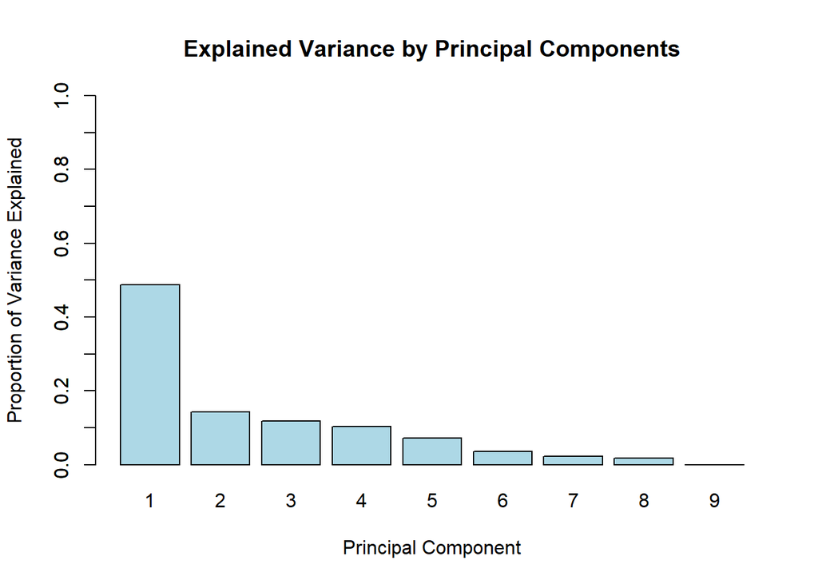

```r
barplot(pca_result_s$sdev^2 / sum(pca_result_s$sdev^2),
        names.arg = 1:length(pca_result_s$sdev),
        xlab = "Principal Component", ylab = "Proportion of Variance Explained",
        main = "Explained Variance by Principal Components",
        ylim = c(0, 1),
        col = "lightblue")
axis(2, at = seq(0, 1, by = 0.1))
```

PC1 describes the largest varience between the variables and PC2 explains the second largest variance between the variables. From this barplot we can see how much each Principal Component explains the variance in our data. We need the first 6 PCs to sufficiently explain the variance because if we sum up all the explained variance of them, we get around 90% of the explained variance.

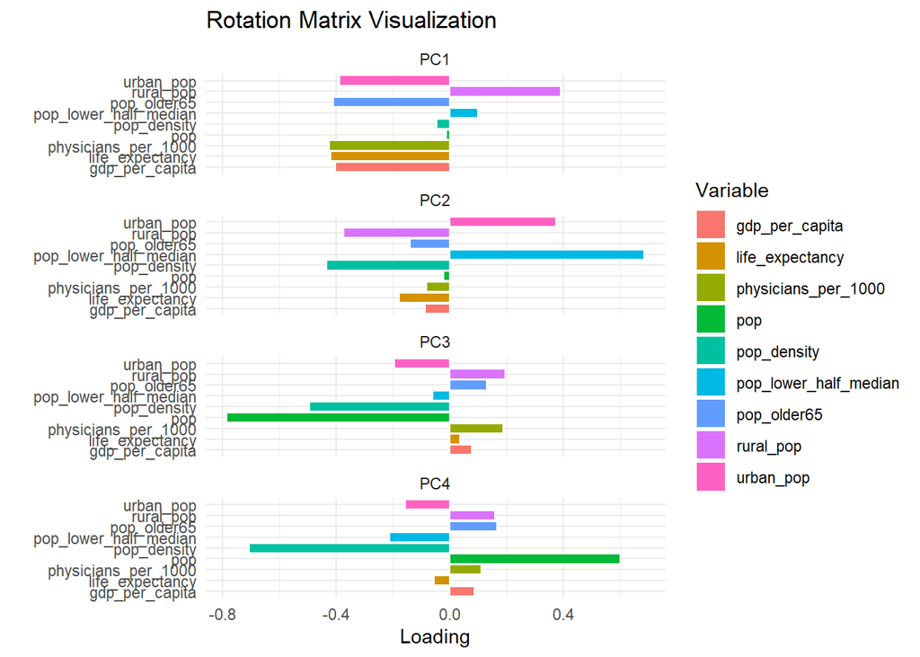

```r
rotation_matrix_s <- pca_result_s$rotation[, 1:4]

rotation_matrix_df_s <- as.data.frame(rotation_matrix_s)|>
  rownames_to_column(var = "Variable")|>
  gather(key = "Principal_Component", value = "Loading", -Variable)

ggplot(rotation_matrix_df_s, aes(x = Loading, y = Variable, fill = Variable)) +
  geom_bar(stat = "identity", position = "dodge", color = "white") +
  labs(title = "Rotation Matrix Visualization",
    x = "Loading",
    y = "",
    fill = "Variable"
  ) +
  theme_minimal() +
  facet_wrap(~ Principal_Component, scales = "free_y", ncol = 1)
```

From these barplot panels we can see the variable loading of each variable for each Principal Component. For the PC1, we can see that most of the variables have a +-0.4 loading where only pop_lower_half_median, pop_density and pop have a very low loading. For PC2, pop_lower_half_median has 0.7 loading and for PC3, pop has almost a -0.8 loading. For PC4, pop_density and pop have the highest loadings.

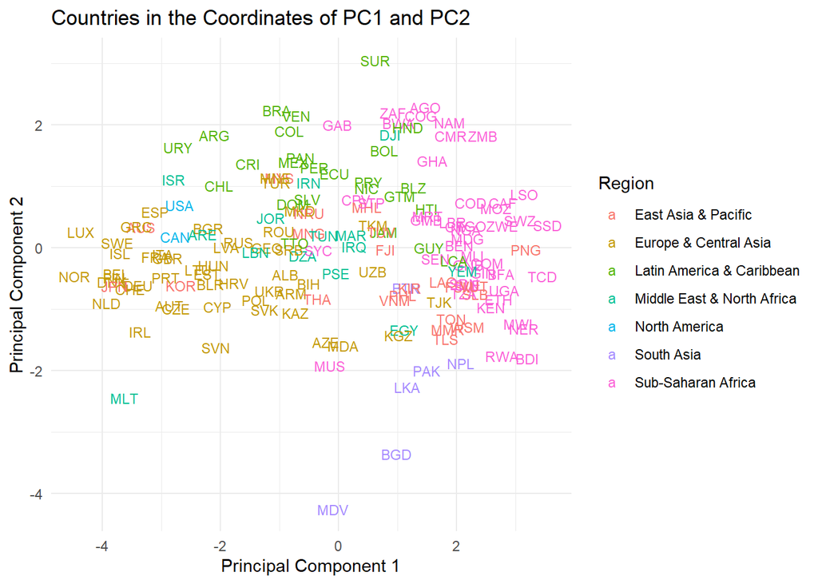

```r
pca_df_s <- data.frame(
  country = wdi_noNA_small$country,
  region = wdi_noNA_small$region,
  iso3c = wdi_noNA_small$iso3c,
  PC1 = pca_result_s$x[, 1],
  PC2 = pca_result_s$x[, 2])

ggplot(pca_df_s, aes(x = PC1, y = PC2, color = region, label = iso3c)) +
  geom_text(size = 3) +
  labs(
    title = "Countries in the Coordinates of PC1 and PC2",
    x = "Principal Component 1",
    y = "Principal Component 2",
    color = "Region"
  ) +
  theme_minimal()
```

Europe & Central Asia group is much different from the Sub-Saharan Africa since they are quite far from each other on the PC1 axis. Europe & Central Asia countries are negative for PC1 which means that with increase of values of these countries the PC1 decreases. Based on this fact, we can conclude that the Europe & Central Asia countries have more urban population, less rural poulation, more population older than 65, more physicians per 1000, higher life expectancy, and higher gdp_per capita. However, Sub-Saharan Africa countries are positive for PC1 which means that with increase of values of these countries the PC1 increases, therefore these countries have less urban population and more rural population, less population older than 65, less physicians per 1000, lower life expectancy and lower gdp per capital.

Another point we can make is that the Latin America & Caribbean countries are different from South Asia countries since they are far away from each other on the PC2 axis. South Asia countries are negative for PC2 which means that with increase of values of these countries the PC2 decreases. Based on this fact, we can conclude that South Asian countries have a much bigger population density and more population who live above 50% of the median income. However, Latin America & Caribbean countries are positive for PC2 which means that with increase of values of these countries the PC2 increases, which means that these countries have more population who live below the 50% of the median income, and lower populaton density.

### 4.0.3 PCA large

Selecting the numeric variables and scaling for the PCA:

```r
wdi_large <- wdi_noNA_large |>
  select_if(is.numeric)

pca_result_l <- prcomp(wdi_large, scale. = TRUE)
```

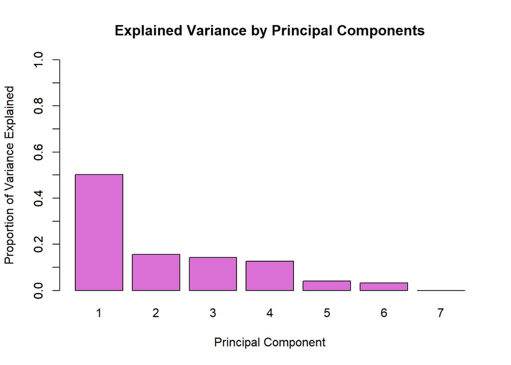

```r
barplot(pca_result_l$sdev^2 / sum(pca_result_l$sdev^2),
        names.arg = 1:length(pca_result_l$sdev),
        xlab = "Principal Component", ylab = "Proportion of Variance Explained",
        main = "Explained Variance by Principal Components",
        ylim = c(0, 1),
        col = "orchid")
axis(2, at = seq(0, 1, by = 0.1))
```

From this barplot we can see how much each Principal Component explains the variance in our data. We need the first 5 PCs to sufficiently explain the variance because if we sum up all the explained variance of them, we get around 90% of the explained variance.

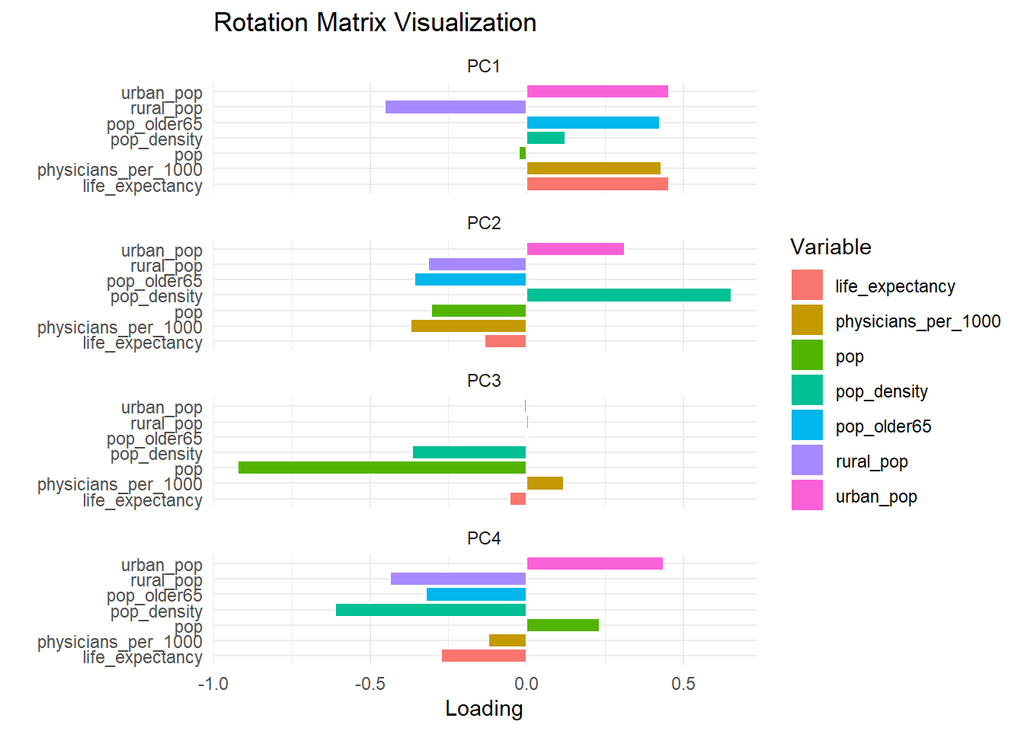

```r
rotation_matrix_l <- pca_result_l$rotation[, 1:4]

rotation_matrix_df_l <- as.data.frame(rotation_matrix_l) %>%
  rownames_to_column(var = "Variable") %>%
  gather(key = "Principal_Component", value = "Loading", -Variable)

ggplot(rotation_matrix_df_l, aes(x = Loading, y = Variable, fill = Variable)) +
  geom_bar(stat = "identity", position = "dodge", color = "white") +
  labs(title = "Rotation Matrix Visualization",
    x = "Loading",
    y = "",
    fill = "Variable"
  ) +
  theme_minimal() +
  facet_wrap(~ Principal_Component, scales = "free_y", ncol = 1)
```

From these barplot panels we can see the loading of each variable for each Principal Component. For the PC1, we can see that most of the variables have almost a +-0.4 loading where only pop_density and pop have a very low loading. For PC2, pop_density has a 0.6 loading and for PC3, pop has almost a -0.9 loading. For PC4 urban_pop and pop_density have the highest loadings.

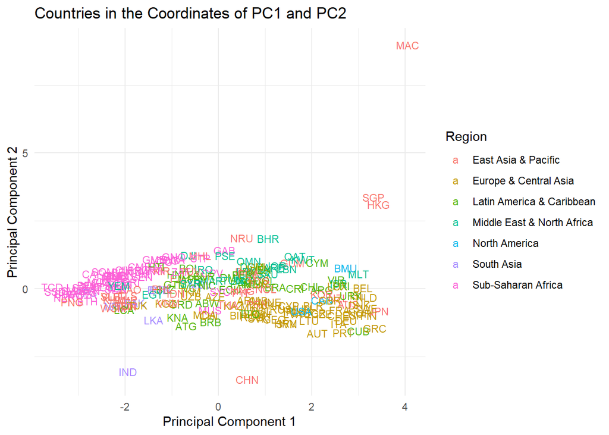

```r
pca_df_l <- data.frame(
  country = wdi_noNA_large$country,
  region = wdi_noNA_large$region,
  iso3c = wdi_noNA_large$iso3c,
  PC1 = pca_result_l$x[, 1],
  PC2 = pca_result_l$x[, 2])

ggplot(pca_df_l, aes(x = PC1, y = PC2, color = region, label = iso3c)) +
  geom_text(size = 3) +
  labs(
    title = "Countries in the Coordinates of PC1 and PC2",
    x = "Principal Component 1",
    y = "Principal Component 2",
    color = "Region"
  ) +
  theme_minimal()
```

In this graphic we can all the countries in the large data frame, with their 3 letter iso codes, each country nearly grouped together based on the region they are in. We can see that the Europe & Central Asia and Latin America & Caribbean countries are clustered near each other showing that they are similar with the patterns in the variation of these principal components.

Firstly, Europe & Central Asia countries are much different from the Sub-Saharan Africa since they are quite far from each other on the PC1 axis. Europe & Central Asia countries are positive for PC1 which means that with increase of values of these countries the PC1 increases. Based on this, we can conclude that the Europe & Central Asia countries have more urban population, less rural poulation, more population older than 65, more physicians per 1000, higher life expectancy. However, Sub-Saharan Africa countries are negative for PC1 which means that with increase of values of these countries the PC1 decreases, these countries have less urban population and more rural population, less population older than 65, less physicians per 1000, lower life expectancy.

Secondly, the Middle East & North Africa countries are different from Europe & Central Asia countries since they are far away from each other on the PC2 axis. Europe & Central Asia countries are negative for PC2 which means that with increase of values of these countries the PC2 decreases, therefore these countries also have a lower population density. However, Middle East & North Africa countries are positive for PC2 which means that with increase of values of these countries the PC2 increases, therefore they have a higher population density and lower rate of physicians per 1000.